# Acropora palmata Demographic Parameters Database

## 3.2 Data Source Composition

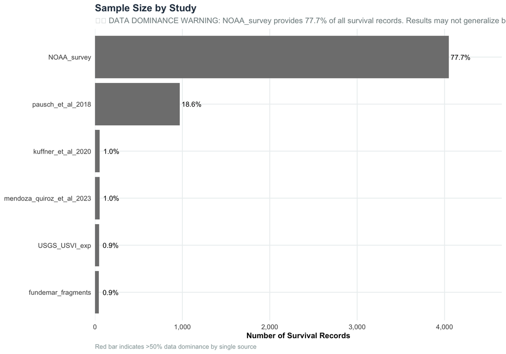

**Figure 1.** Sample size by study. NOAA surveys dominate the dataset (78% of survival records), which has implications for generalizability.

```r
# Calculate actual proportions from data
study_composition <- survival_data %>%
  count(study, name = "n") %>%
  mutate(
    pct = n / sum(n),
    label = paste0(study, "\n(n=", fmt_num(n, 0), ", ", fmt_pct(pct), ")")
  ) %>%
  arrange(desc(n))

# Dominant study check
dominant_study <- study_composition %>% slice(1)
if (dominant_study$pct > 0.5) {
  warning_msg <- paste0(
    "⚠️ DATA DOMINANCE WARNING: ", dominant_study$study,
    " provides ", fmt_pct(dominant_study$pct),
    " of all survival records. Results may not generalize beyond this study's context."
  )
} else {
  warning_msg <- NULL
}

# Visualization
ggplot(study_composition, aes(x = reorder(study, n), y = n)) +
  geom_col(aes(fill = pct > 0.5), show.legend = FALSE) +
  geom_text(aes(label = fmt_pct(pct)), hjust = -0.1, size = 3.5) +
  coord_flip() +
  scale_fill_manual(values = c("FALSE" = colors_coral["field"], "TRUE" = colors_coral["fragment"])) +
  scale_y_continuous(labels = scales::comma, expand = expansion(mult = c(0, 0.15))) +
  labs(
    title = "Sample Size by Study",
    subtitle = warning_msg,
    x = NULL,
    y = "Number of Survival Records",
    caption = "Red bar indicates >50% data dominance by single source"
  )
```

**Critical Issue: Data Dominance**

NOAA Tagged Colony Surveys provide **77.7%** of survival data. This means:

1. Results are biased toward **large, naturally-occurring field colonies** in Florida Keys and Curaçao
2. Size class 5 (>2000 cm²) estimates come almost exclusively from NOAA
3. **Generalizing to restoration fragments or other regions requires extreme caution**

# 4 Where Did We Synthesize Data From?

## 4.1 The Data Synthesis Challenge

This database represents **the largest synthesis of *Acropora palmata* demographic data ever compiled**, but understanding where the data came from is essential for proper interpretation.

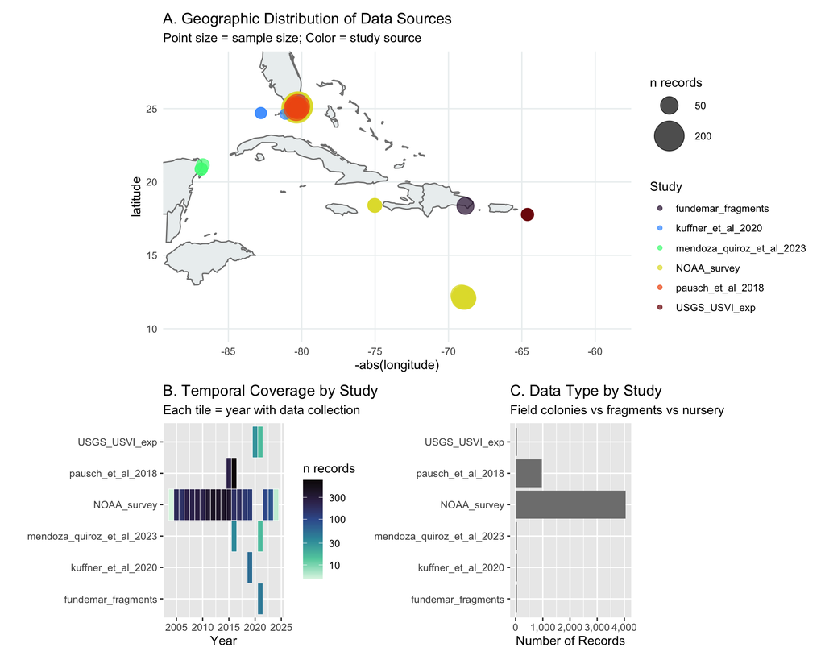

**Figure 2.** Geographic and temporal distribution of synthesized data sources. A) Map of study locations with sample sizes. B) Temporal coverage by study. C) Data type breakdown.

```r
# Prepare location data
location_summary <- survival_data %>%
  filter(!is.na(latitude), !is.na(longitude)) %>%
  group_by(study, region, location, latitude, longitude) %>%
  summarise(
    n_survival = n(),
    n_years = n_distinct(survey_yr),
    year_range = paste(min(survey_yr), max(survey_yr), sep = "–"),
    data_type = first(data_type),
    .groups = "drop"
  )

# Map
library(ggplot2)

# Get Caribbean basemap coordinates
caribbean_bbox <- list(
  xmin = -88, xmax = -59,
  ymin = 10, ymax = 28
)

p_map <- ggplot() +
  # Simple coastline approximation using world map borders
  borders("world", regions = c("USA", "Cuba", "Jamaica", "Haiti", "Dominican Republic",
                                "Puerto Rico", "Mexico", "Belize", "Honduras",
                                "Bahamas", "Cayman Islands", "Turks and Caicos Islands"),
          fill = "#ECF0F1", color = "#BDC3C7") +
  geom_point(data = location_summary,
             aes(x = -abs(longitude), y = latitude, size = n_survival, color = study),
             alpha = 0.7) +
  scale_size_continuous(range = c(2, 12), breaks = c(50, 200, 1000, 3000),
                        name = "n records") +
  scale_color_viridis_d(option = "turbo", name = "Study") +
  coord_sf(xlim = c(caribbean_bbox$xmin, caribbean_bbox$xmax),
           ylim = c(caribbean_bbox$ymin, caribbean_bbox$ymax)) +
  labs(title = "A. Geographic Distribution of Data Sources",
       subtitle = "Point size = sample size; Color = study source") +
  theme_minimal() +
  theme(legend.position = "right",
        panel.grid = element_line(color = "#ECF0F1"))

# Temporal coverage
temporal_data <- survival_data %>%
  group_by(study, survey_yr) %>%
  summarise(n = n(), .groups = "drop")

p_temporal <- ggplot(temporal_data, aes(x = survey_yr, y = study, fill = n)) +
  geom_tile(color = "white") +
  scale_fill_viridis_c(option = "mako", direction = -1, name = "n records",
                       trans = "log10") +
  scale_x_continuous(breaks = seq(2005, 2025, 5)) +
  labs(title = "B. Temporal Coverage by Study",
       subtitle = "Each tile = year with data collection",
       x = "Year", y = NULL)

# Data type breakdown
data_type_summary <- survival_data %>%
  count(study, data_type, fragment) %>%
  mutate(
    category = case_when(
      data_type == "field" & fragment == "N" ~ "Field colonies",
      data_type == "field" & fragment == "Y" ~ "Field fragments",
      data_type == "nursery_in" ~ "In situ nursery",
      data_type == "nursery_ex" ~ "Ex situ nursery",
      TRUE ~ "Other"
    )
  )

p_type <- ggplot(data_type_summary, aes(x = study, y = n, fill = category)) +
  geom_col(position = "stack") +
  coord_flip() +
  scale_fill_manual(values = c(
    "Field colonies" = colors_coral["field"],
    "Field fragments" = colors_coral["nursery_in"],
    "In situ nursery" = colors_coral["nursery_ex"],
    "Ex situ nursery" = colors_coral["fragment"],
    "Other" = colors_coral["neutral"]
  ), name = "Data Type") +
  scale_y_continuous(labels = scales::comma) +
  labs(title = "C. Data Type by Study",
       subtitle = "Field colonies vs fragments vs nursery",
       x = NULL, y = "Number of Records")

# Combine
library(patchwork)
p_map / (p_temporal | p_type) + plot_layout(heights = c(1.5, 1))
```

## 4.2 Data Sources: The Full Story

We synthesized data from **6 primary studies** spanning **2004 to 2024**:

```r
# Create detailed study information table
study_details <- survival_data %>%
  group_by(study) %>%
  summarise(
    `n (survival)` = n(),
    `n (growth)` = sum(study %in% growth_data$study),
    Regions = paste(unique(region), collapse = ", "),
    `Year Range` = paste(min(survey_yr), max(survey_yr), sep = "–"),
    `Data Type` = paste(unique(data_type), collapse = ", "),
    `Fragment %` = fmt_pct(mean(fragment == "Y", na.rm = TRUE)),
    .groups = "drop"
  ) %>%
  mutate(
    `% of Total` = fmt_pct(`n (survival)` / sum(`n (survival)`))
  ) %>%
  arrange(desc(`n (survival)`))

study_details %>%
  kable(caption = "**Table 2a.** Detailed breakdown of data sources. Each study contributes differently to the synthesis.") %>%
  kable_styling(bootstrap_options = c("striped", "hover", "condensed"),
                font_size = 11, full_width = TRUE) %>%
  row_spec(1, bold = TRUE, background = "#FEF9E7")  # Highlight dominant study
```

**Table 2a.** Detailed breakdown of data sources. Each study contributes differently to the synthesis.

[output not shown]

### 4.2.1 Study Descriptions

```r
# Narrative descriptions of each study
study_narratives <- tribble(
  ~Study, ~Description, ~`Key Contribution`, ~Caveats,
  "NOAA_survey", "Long-term tagged colony monitoring in FL Keys, Curaçao, and Navassa (2004–2024). Individual colonies tracked annually.", "78% of survival data; only source for large adults (SC5)", "Dominated by FL Keys; large colonies only",
  "pausch_et_al_2018", "Experimental fragment restoration study in Florida Keys nursery and outplant sites", "Best data on nursery fragment growth and survival", "Small fragments only; specific restoration context",
  "kuffner_et_al_2020", "Florida Keys fragment study with controlled experimental design", "High-quality controlled data", "Limited sample size; specific experimental conditions",
  "mendoza_quiroz_et_al_2023", "Mexican Caribbean restoration monitoring", "Extends geographic range to Mexico", "Recent study; limited temporal depth",
  "USGS_USVI_exp", "USVI experimental transplant study", "Only USVI representation", "Small sample size; experimental context",
  "fundemar_fragments", "Dominican Republic community-based restoration", "Eastern Caribbean representation", "Fragment-only; specific site conditions"
)

study_narratives %>%
  kable(caption = "**Table 2b.** Study context and caveats for interpretation.") %>%
  kable_styling(bootstrap_options = c("striped", "hover")) %>%
  column_spec(2, width = "30%") %>%
  column_spec(4, width = "25%")
```

**Table 2b.** Study context and caveats for interpretation.

| Study | Description | Key Contribution | Caveats |
| --- | --- | --- | --- |
| NOAA_survey | Long-term tagged colony monitoring in FL Keys, Curaçao, and Navassa (2004–2024). Individual colonies tracked annually. | 78% of survival data; only source for large adults (SC5) | Dominated by FL Keys; large colonies only |
| pausch_et_al_2018 | Experimental fragment restoration study in Florida Keys nursery and outplant sites | Best data on nursery fragment growth and survival | Small fragments only; specific restoration context |
| kuffner_et_al_2020 | Florida Keys fragment study with controlled experimental design | High-quality controlled data | Limited sample size; specific experimental conditions |
| mendoza_quiroz_et_al_2023 | Mexican Caribbean restoration monitoring | Extends geographic range to Mexico | Recent study; limited temporal depth |
| USGS_USVI_exp | USVI experimental transplant study | Only USVI representation | Small sample size; experimental context |
| fundemar_fragments | Dominican Republic community-based restoration | Eastern Caribbean representation | Fragment-only; specific site conditions |

## 4.3 Geographic Coverage Gaps

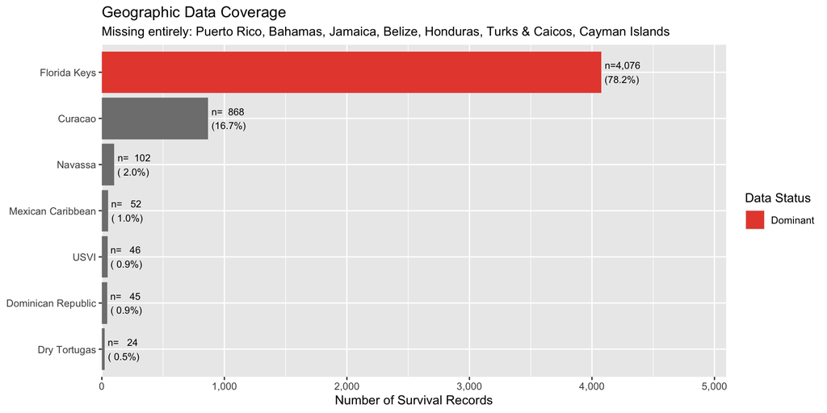

**Figure 3.** Sample size by Caribbean region. Note the severe underrepresentation of Eastern Caribbean (Puerto Rico, USVI, BVI) and complete absence of several island nations.

```r
# Regional breakdown
region_summary <- survival_data %>%
  count(region, name = "n") %>%
  mutate(
    pct = n / sum(n),
    status = case_when(
      pct > 0.5 ~ "Dominant",
      n >= 100 ~ "Adequate",
      n >= 30 ~ "Limited",
      TRUE ~ "Critical gap"
    )
  ) %>%
  arrange(desc(n))

# Add missing regions
missing_regions <- c("Puerto Rico", "Bahamas", "Jamaica", "Belize",
                     "Honduras", "Turks & Caicos", "Cayman Islands")

ggplot(region_summary, aes(x = reorder(region, n), y = n)) +
  geom_col(aes(fill = status)) +
  geom_text(aes(label = paste0("n=", fmt_num(n, 0), "\n(", fmt_pct(pct), ")")),
            hjust = -0.1, size = 3) +
  coord_flip() +
  scale_fill_manual(values = c(
    "Dominant" = "#E74C3C",
    "Adequate" = colors_coral["field"],
    "Limited" = colors_coral["nursery_ex"],
    "Critical gap" = colors_coral["neutral"]
  ), name = "Data Status") +
  scale_y_continuous(labels = scales::comma, expand = expansion(mult = c(0, 0.25))) +
  labs(
    title = "Geographic Data Coverage",
    subtitle = paste0("Missing entirely: ", paste(missing_regions, collapse = ", ")),
    x = NULL,
    y = "Number of Survival Records"
  )
```

**Geographic Bias Alert**

- **Florida Keys dominates**: 78.2% of all data
- **Eastern Caribbean underrepresented**: USVI, Puerto Rico, BVI have <3% of data combined
- **No data from**: Jamaica, Bahamas, Belize, Honduras, Turks & Caicos

Results may not generalize to under-sampled regions where environmental conditions differ.

## 4.4 Fragment vs. Colony Confound

One of the most critical data issues: **size classes are confounded with data type**.

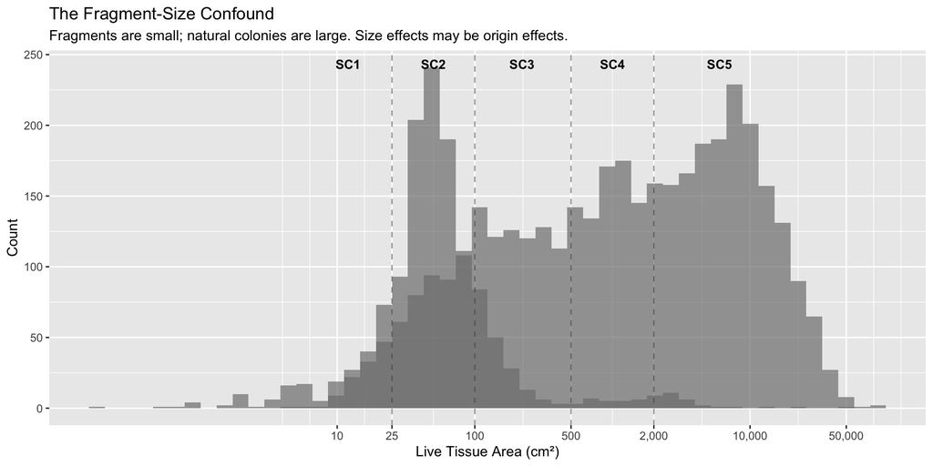

**Figure 4.** Size distribution by fragment status and study. Fragments cluster in SC1-SC2; natural colonies cluster in SC4-SC5. This creates a confound between size and origin.

```r
# Show the confound
survival_data %>%
  filter(!is.na(size_live_cm2), !is.na(fragment)) %>%
  mutate(
    origin = ifelse(fragment == "Y", "Fragment", "Natural colony")
  ) %>%
  ggplot(aes(x = size_live_cm2, fill = origin)) +
  geom_histogram(alpha = 0.7, position = "identity", bins = 50) +
  geom_vline(xintercept = c(25, 100, 500, 2000), linetype = "dashed",
             color = colors_coral["neutral"], alpha = 0.5) +
  scale_x_log10(labels = scales::comma,
                breaks = c(10, 25, 100, 500, 2000, 10000, 50000)) +
  scale_fill_manual(values = c("Fragment" = colors_coral["fragment"],
                               "Natural colony" = colors_coral["field"])) +
  annotate("text", x = c(12, 50, 220, 1000, 6000), y = Inf,
           label = c("SC1", "SC2", "SC3", "SC4", "SC5"),
           vjust = 2, size = 3.5, fontface = "bold") +
  labs(
    title = "The Fragment-Size Confound",
    subtitle = "Fragments are small; natural colonies are large. Size effects may be origin effects.",
    x = "Live Tissue Area (cm²)",
    y = "Count",
    fill = "Origin"
  )
```

**Key insight:** Fragments cluster in SC1-SC2; natural colonies cluster in SC4-SC5. This creates a fundamental confound between size and origin that affects all analyses.

# 5 Understanding the Data Structure

## 5.1 The Critical Size Variable Distinction

There are **two size measurements** in this dataset. Using the wrong one leads to incorrect biological conclusions.

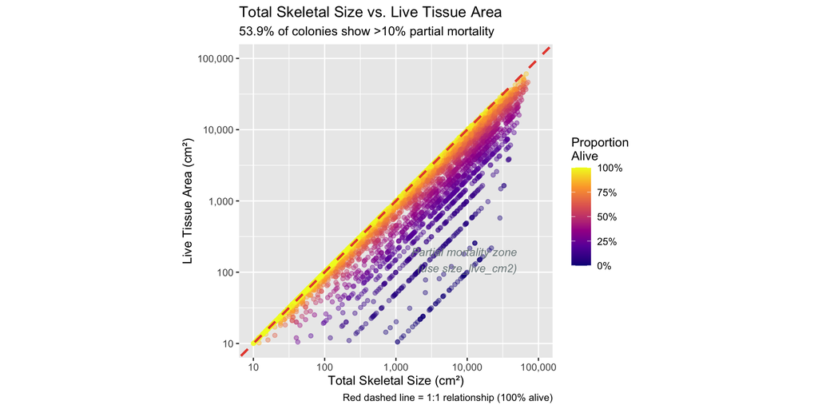

**Figure 5.** Total skeletal size vs. live tissue area. Points below the 1:1 line (red dashed) indicate partial mortality. A colony with 5,000 cm² skeleton but only 500 cm² live tissue behaves biologically like a small coral, not a large one.

```r
# Filter to valid records
size_comparison <- survival_data %>%
  filter(!is.na(size_cm2), !is.na(size_live_cm2),
         size_cm2 > 0, size_live_cm2 > 0) %>%
  mutate(
    pct_alive = size_live_cm2 / size_cm2,
    partial_mortality = pct_alive < 0.9
  )

# Calculate statistics
pct_partial_mort <- mean(size_comparison$partial_mortality)
median_pct_alive <- median(size_comparison$pct_alive)

# Visualization with annotations
ggplot(size_comparison, aes(x = size_cm2, y = size_live_cm2)) +
  geom_point(aes(color = pct_alive), alpha = 0.4, size = 1.5) +
  geom_abline(slope = 1, intercept = 0, linetype = "dashed", color = "#E74C3C", linewidth = 1) +
  scale_x_log10(labels = scales::comma, limits = c(10, 100000)) +
  scale_y_log10(labels = scales::comma, limits = c(10, 100000)) +
  scale_color_viridis_c(
    name = "Proportion\nAlive",
    option = "plasma",
    limits = c(0, 1),
    labels = scales::percent
  ) +
  labs(
    title = "Total Skeletal Size vs. Live Tissue Area",
    subtitle = paste0(fmt_pct(pct_partial_mort), " of colonies show >10% partial mortality"),
    x = "Total Skeletal Size (cm²)",
    y = "Live Tissue Area (cm²)",
    caption = "Red dashed line = 1:1 relationship (100% alive)"
  ) +
  annotate("text", x = 50000, y = 100, label = "Partial mortality zone\n(use size_live_cm2)",
           hjust = 1, vjust = 0, size = 3.5, fontface = "italic", color = "#7F8C8D") +
  coord_fixed()
```

**Rule: Always use `size_live_cm2` for biological analyses.** The `size_cm2` variable (total skeletal footprint) includes dead skeleton and misrepresents the coral’s biological state.

## 5.2 Size Class Definitions

```r
# Define size classes with biological rationale
size_class_info <- tribble(
  ~Class, ~Range_cm2, ~Description, ~Biological_Rationale,
  "SC1", "0–25", "Recruits/small fragments", "Recently settled or fragmented; highest vulnerability",
  "SC2", "25–100", "Small juveniles", "Establishing but still highly vulnerable",
  "SC3", "100–500", "Large juveniles", "Transition zone; approaching reproductive maturity",
  "SC4", "500–2,000", "Small adults", "Reproductively mature; lower mortality",
  "SC5", ">2,000", "Large adults", "Established; lowest mortality; highest reproductive output"
)

size_class_info %>%
  kable(caption = "**Table 3.** Size class definitions based on live tissue area (cm²).") %>%
  kable_styling(bootstrap_options = c("striped", "hover")) %>%
  column_spec(4, width = "40%")
```

**Table 3.** Size class definitions based on live tissue area (cm²).

| Class | Range_cm2 | Description | Biological_Rationale |
| --- | --- | --- | --- |
| SC1 | 0–25 | Recruits/small fragments | Recently settled or fragmented; highest vulnerability |
| SC2 | 25–100 | Small juveniles | Establishing but still highly vulnerable |
| SC3 | 100–500 | Large juveniles | Transition zone; approaching reproductive maturity |
| SC4 | 500–2,000 | Small adults | Reproductively mature; lower mortality |
| SC5 | >2,000 | Large adults | Established; lowest mortality; highest reproductive output |

```r
# Assign size classes
size_breaks <- c(0, 25, 100, 500, 2000, Inf)
size_labels <- c("SC1", "SC2", "SC3", "SC4", "SC5")

survival_data <- survival_data %>%
  mutate(
    size_class = cut(size_live_cm2, breaks = size_breaks, labels = size_labels,
                     include.lowest = TRUE, right = FALSE),
    log_size = log10(size_live_cm2)
  )

growth_data <- growth_data %>%
  mutate(
    size_class = cut(size_live_cm2, breaks = size_breaks, labels = size_labels,
                     include.lowest = TRUE, right = FALSE),
    log_size = log10(size_live_cm2),
    # Calculate RGR
    RGR = growth_live_cm2_yr / size_live_cm2
  ) %>%
  filter(is.finite(RGR), abs(RGR) < 10)  # Remove infinite/extreme values
```

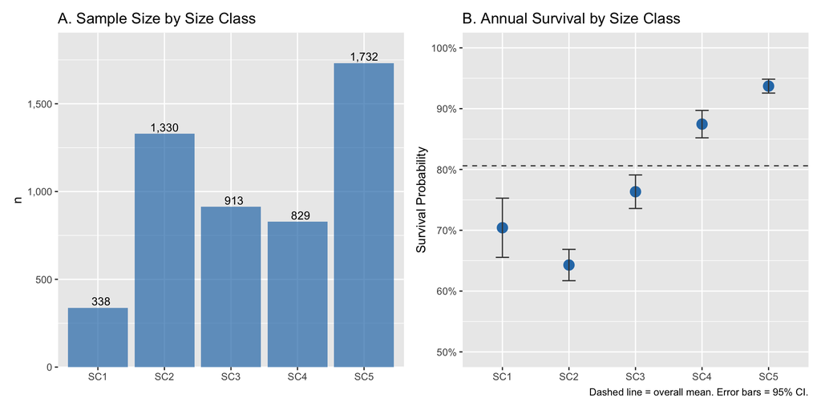

```r
# Calculate survival by size class with proper CIs
size_class_summary <- survival_data %>%
  filter(!is.na(size_class), !is.na(survived)) %>%
  group_by(size_class) %>%
  summarise(
    n = n(),
    survived_n = sum(survived),
    survival = mean(survived),
    # Wilson score interval for proportions
    se = sqrt(survival * (1 - survival) / n),
    ci_lower = survival - 1.96 * se,
    ci_upper = survival + 1.96 * se,
    .groups = "drop"
  ) %>%
  mutate(
    ci_lower = pmax(0, ci_lower),
    ci_upper = pmin(1, ci_upper)
  )

# Combined plot: sample size bars + survival points
p1 <- ggplot(size_class_summary, aes(x = size_class, y = n)) +
  geom_col(fill = colors_coral["field"], alpha = 0.7) +
  geom_text(aes(label = fmt_num(n, 0)), vjust = -0.3, size = 3.5) +
  scale_y_continuous(labels = scales::comma, expand = expansion(mult = c(0, 0.1))) +
  labs(title = "A. Sample Size by Size Class", x = NULL, y = "n")

p2 <- ggplot(size_class_summary, aes(x = size_class, y = survival)) +
  geom_point(size = 4, color = colors_coral["field"]) +
  geom_errorbar(aes(ymin = ci_lower, ymax = ci_upper), width = 0.2, color = colors_coral["neutral"]) +
  geom_hline(yintercept = mean(survival_data$survived, na.rm = TRUE),
             linetype = "dashed", color = colors_coral["neutral"]) +
  scale_y_continuous(labels = scales::percent, limits = c(0.5, 1)) +
  labs(title = "B. Annual Survival by Size Class", x = NULL, y = "Survival Probability",
       caption = "Dashed line = overall mean. Error bars = 95% CI.")

p1 + p2 + plot_layout(widths = c(1, 1))
```

# 6 Analysis 1: Size-Survival Relationship

## 6.1 Exploratory Analysis

Before fitting models, we examine the raw data distribution and check for patterns that might affect our analysis.

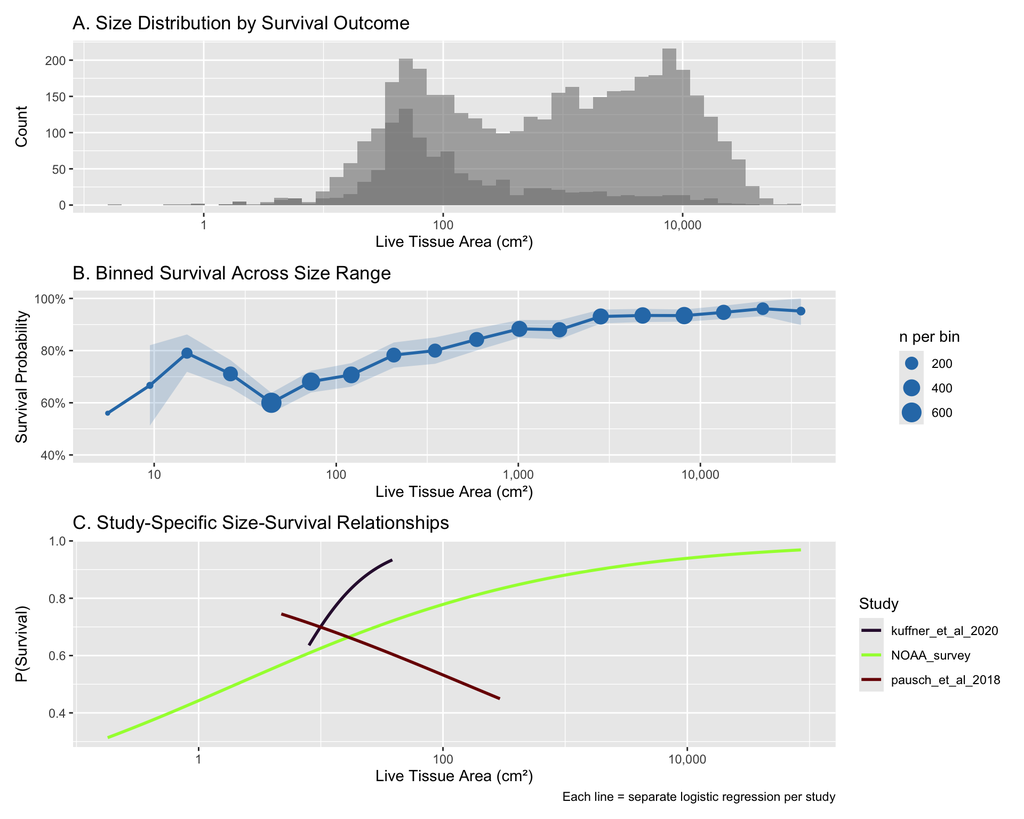

**Figure 7.** Exploratory analysis of survival data. A) Size distribution by survival outcome. B) Survival across the size range with binned means. C) Study-specific patterns showing heterogeneity.

```r
# Panel A: Size distribution by outcome
p_dist <- survival_data %>%
  filter(!is.na(size_live_cm2), size_live_cm2 > 0, !is.na(survived)) %>%
  mutate(outcome = ifelse(survived == 1, "Survived", "Died")) %>%
  ggplot(aes(x = size_live_cm2, fill = outcome)) +
  geom_histogram(position = "identity", alpha = 0.6, bins = 50) +
  scale_x_log10(labels = scales::comma) +
  scale_fill_manual(values = c("Survived" = colors_coral["highlight"], "Died" = colors_coral["fragment"])) +
  labs(title = "A. Size Distribution by Survival Outcome", x = "Live Tissue Area (cm²)", y = "Count", fill = NULL)

# Panel B: Binned survival across size range
p_binned <- survival_data %>%
  filter(!is.na(size_live_cm2), size_live_cm2 > 0, !is.na(survived)) %>%
  mutate(size_bin = cut(log10(size_live_cm2), breaks = 25)) %>%
  group_by(size_bin) %>%
  filter(n() >= 20) %>%
  summarise(
    survival = mean(survived),
    n = n(),
    se = sqrt(survival * (1 - survival) / n),
    mean_size = 10^mean(log10(size_live_cm2), na.rm = TRUE),
    .groups = "drop"
  ) %>%
  ggplot(aes(x = mean_size, y = survival)) +
  geom_ribbon(aes(ymin = survival - 1.96*se, ymax = pmin(1, survival + 1.96*se)),
              alpha = 0.2, fill = colors_coral["field"]) +
  geom_line(color = colors_coral["field"], linewidth = 1) +
  geom_point(aes(size = n), color = colors_coral["field"]) +
  scale_x_log10(labels = scales::comma) +
  scale_y_continuous(labels = scales::percent, limits = c(0.4, 1)) +
  labs(title = "B. Binned Survival Across Size Range", x = "Live Tissue Area (cm²)",
       y = "Survival Probability", size = "n per bin")

# Panel C: By study
p_study <- survival_data %>%
  filter(!is.na(size_live_cm2), size_live_cm2 > 0, !is.na(survived)) %>%
  group_by(study) %>%
  filter(n() >= 50) %>%
  ungroup() %>%
  ggplot(aes(x = size_live_cm2, y = survived, color = study)) +
  geom_smooth(method = "glm", method.args = list(family = "binomial"), se = FALSE, linewidth = 1) +
  scale_x_log10(labels = scales::comma) +
  scale_color_viridis_d(option = "turbo") +
  labs(title = "C. Study-Specific Size-Survival Relationships",
       x = "Live Tissue Area (cm²)", y = "P(Survival)", color = "Study",
       caption = "Each line = separate logistic regression per study")

(p_dist / p_binned / p_study) + plot_layout(heights = c(1, 1, 1.2))
```

## 6.2 Model Fitting

We fit multiple models to characterize the size-survival relationship and compare their performance.

```r
# Prepare data for modeling
model_data <- survival_data %>%
  filter(!is.na(size_live_cm2), size_live_cm2 > 0, !is.na(survived)) %>%
  mutate(log_size = log10(size_live_cm2))

# Model 1: Simple logistic regression
mod_logistic <- glm(survived ~ log_size, data = model_data, family = binomial)

# Model 2: GAM for nonlinearity
# NOTE: Using k=3 to constrain smoothness (allows at most 1 bend)
# This prevents overfitting wiggly patterns that aren't biologically meaningful
mod_gam <- mgcv::gam(survived ~ s(log_size, k = 3), data = model_data, family = binomial)

# Model 3: Mixed-effects model with study random intercept
mod_mixed <- lme4::glmer(survived ~ log_size + (1|study), data = model_data, family = binomial)

# Model comparison
model_comparison <- tibble(
  Model = c("Logistic (size only)", "GAM (nonlinear)", "Mixed-effects (study RE)"),
  AIC = c(AIC(mod_logistic), AIC(mod_gam), AIC(mod_mixed)),
  Deviance = c(deviance(mod_logistic), deviance(mod_gam), deviance(mod_mixed)),
  df = c(2, sum(mod_gam$edf) + 1, 3)
) %>%
  mutate(
    Delta_AIC = AIC - min(AIC),
    Preferred = Delta_AIC == 0
  )

model_comparison %>%
  kable(digits = 1, caption = "**Table 4.** Model comparison for size-survival relationship.") %>%
  kable_styling(bootstrap_options = c("striped", "hover"), full_width = FALSE) %>%
  row_spec(which(model_comparison$Preferred), bold = TRUE, background = "#d4edda")
```

**Table 4.** Model comparison for size-survival relationship.

| Model | AIC | Deviance | df | Delta_AIC | Preferred |
| --- | --- | --- | --- | --- | --- |
| Logistic (size only) | 4601.8 | 4597.8 | 2.0 | 85.9 | FALSE |
| GAM (nonlinear) | 4592.3 | 4586.5 | 3.9 | 76.4 | FALSE |
| Mixed-effects (study RE) | 4515.9 | 4491.7 | 3.0 | 0.0 | TRUE |

```r
# Extract and display model coefficients
tidy(mod_logistic, conf.int = TRUE, exponentiate = TRUE) %>%
  mutate(
    term = case_when(
      term == "(Intercept)" ~ "Intercept",
      term == "log_size" ~ "log₁₀(Size) — OR per 10× size increase"
    )
  ) %>%
  select(Term = term, `Odds Ratio` = estimate, `95% CI Lower` = conf.low,
         `95% CI Upper` = conf.high, `p-value` = p.value) %>%
  kable(digits = 3, caption = "**Table 5.** Logistic regression coefficients (exponentiated as odds ratios).") %>%
  kable_styling(bootstrap_options = c("striped", "hover"), full_width = FALSE)
```

**Table 5.** Logistic regression coefficients (exponentiated as odds ratios).

| Term | Odds Ratio | 95% CI Lower | 95% CI Upper | p-value |
| --- | --- | --- | --- | --- |
| Intercept | 0.504 | 0.412 | 0.617 | 0 |
| log₁₀(Size) — OR per 10× size increase | 2.340 | 2.154 | 2.546 | 0 |

```r
# Calculate pseudo-R² (McFadden)
null_dev <- mod_logistic$null.deviance
resid_dev <- mod_logistic$deviance
mcfadden_r2 <- 1 - (resid_dev / null_dev)

# Tjur's R² (discrimination)
pred_probs <- predict(mod_logistic, type = "response")
tjur_r2 <- mean(pred_probs[model_data$survived == 1]) - mean(pred_probs[model_data$survived == 0])
```

### 6.2.1 Model Performance

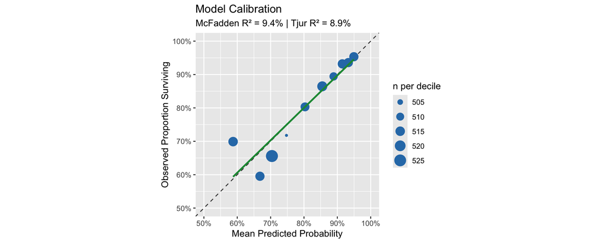

**Figure 8.** Model calibration plot. Points show observed survival in deciles of predicted probability. Perfect calibration would follow the diagonal.

```r
# Calibration plot
model_data %>%
  mutate(
    pred_prob = predict(mod_logistic, type = "response"),
    prob_decile = cut(pred_prob, breaks = quantile(pred_prob, probs = seq(0, 1, 0.1)), include.lowest = TRUE)
  ) %>%
  group_by(prob_decile) %>%
  summarise(
    observed = mean(survived),
    predicted = mean(pred_prob),
    n = n(),
    .groups = "drop"
  ) %>%
  ggplot(aes(x = predicted, y = observed)) +
  geom_abline(slope = 1, intercept = 0, linetype = "dashed", color = colors_coral["neutral"]) +
  geom_point(aes(size = n), color = colors_coral["field"]) +
  geom_smooth(method = "lm", se = FALSE, color = colors_coral["highlight"]) +
  scale_x_continuous(labels = scales::percent, limits = c(0.5, 1)) +
  scale_y_continuous(labels = scales::percent, limits = c(0.5, 1)) +
  labs(
    title = "Model Calibration",
    subtitle = paste0("McFadden R² = ", fmt_pct(mcfadden_r2), " | Tjur R² = ", fmt_pct(tjur_r2)),
    x = "Mean Predicted Probability",
    y = "Observed Proportion Surviving",
    size = "n per decile"
  ) +
  coord_fixed()
```

**Key Result: Size Explains Only ~9% of Survival Variance**

- **McFadden R² = 9.4%**
- **Tjur R² = 8.9%**

This means **>90% of survival variation is explained by factors other than size**: study methodology, region, year, disturbance history, fragment origin, and unmeasured factors.

**Implication:** Size-based predictions will have wide uncertainty. Context matters more than size.